# TFCB Capstone Question 1

Amin Addetia

12/15/2020

# About the data

The dataset here represents various features measures from 499 healthy or glaucoma-positive individuals. The dataset was then split into a training set with records for 399 individuals for a machine learning model and a test set with records for the remaining 100 individuals.

I assumed the OD/OS metadata provided in the table did not affect any of the features and that each entry was for a single individual. Additional documentation on the features analyzed would have improved by ability to use and interpet the results from this dataset.

# Impact of age and glaucoma status on candidate features used to develop a machine learning model for diagnosing glaucoma

The dataset analyzed here examines various features in individuals diagnosed with glaucoma compared to healthy individuals and then builds uses these data to build a machine learning model for diagnosing glaucoma. The model asssumes that each the of the factors are equally predictive regardless of the individual’s age and uses the individual’s age in the machine learning diagnosis decision tree. Here, I examine that underlying assumption by asking the following question: Are certain measured factors better predictors of glaucoma status for particular age groups or are all factors equally good predictors of glaucoma status regardless of an individual’s age?

## Reading in dataset and generating summary statistics for groups stratified by age and glaucoma status

This section reads in the ds_whole.csv file and outputs the summary file age_group_glaucoma_summary_statistics.csv.

```r
#Reading in dataset

dataset <- read.csv('data/ds_whole.csv', header = T)

#Reassigning variables in glaucoma column to make more human readable

dataset %>%
  mutate(glaucoma=case_when(glaucoma == 0 ~ 'No',
                   glaucoma == 1 ~ 'Yes'), .keep = 'unused') -> dataset

#Adding a new column with age group for each observation, which is based on the age column

dataset %>%
  mutate(age_group=case_when(age <= 20 ~ '20 yo and under',
                             age >= 21 & age <= 35 ~ '21-35 yo',
                             age >= 36 & age <= 50 ~ '36-50 yo',
                             age >= 51 & age <= 65 ~ '51-65 yo',
                             age >= 66 & age <= 80 ~ '66-80 yo',
                             age > 80 ~ '80 yo and over')) -> dataset

#Summarize the data based on glaucoma status and age group

dataset %>%
  group_by(age_group, glaucoma) %>%
  summarise_all(funs(mean)) -> summary
#Dropping the RL column

summary <- subset(summary, select = -c(RL))

#Renaming the column headers to make them more human-readable

summary %>%
  rename( 'Age Group'= age_group,
          Glaucoma = glaucoma,
          'Mean Age' = age,
          'Mean ocular pressure' = ocular_pressure,
          'Mean MD' = MD,
          'Mean PSD' = PSD,
          'Mean GHT' = GHT,
          'Mean cornea thickness' = cornea_thickness,
          'Mean RNFL thickness' = RNFL4.mean) -> summary

#Displaying the summary statistics

print(summary)
```

```
## # A tibble: 11 x 9
## # Groups:   Age Group [6]
##    `Age Group` Glaucoma `Mean Age` `Mean ocular pr… `Mean MD` `Mean PSD`
##    <chr>       <chr>         <dbl>            <dbl>     <dbl>      <dbl>
##  1 20 yo and … No             14.6             15.9     -3.04       2.23
##  2 21-35 yo    No             27.6             15.6     -1.96       1.58
##  3 21-35 yo    Yes            28               18       -6.91       7.94
##  4 36-50 yo    No             43.9             17.2     -1.25       1.90
##  5 36-50 yo    Yes            44.6             25.6     -9.88       8.75
##  6 51-65 yo    No             57.4             16.6     -1.91       2.14
##  7 51-65 yo    Yes            57.8             25.9    -13.3        8.32
##  8 66-80 yo    No             72.1             15.0     -2.97       2.86
##  9 66-80 yo    Yes            72.2             22.3    -14.3        6.68
## 10 80 yo and … No             83.4             17       -3.57       3.09
## 11 80 yo and … Yes            84.4             22.1    -22.1        7.84
## # … with 3 more variables: `Mean GHT` <dbl>, `Mean cornea thickness` <dbl>,
## #   `Mean RNFL thickness` <dbl>
```

```r
#Creating a csv file with the summary statistics

write.csv(summary, 'results/age_group_glaucoma_summary_statistics.csv', row.names = F)
```

## Plotting data stratified by age group and glaucoma.

This section takes the summary table generated in the chunk above and outputs plots for each of the candidate features in the age_group_glaucoma_plots.png file.

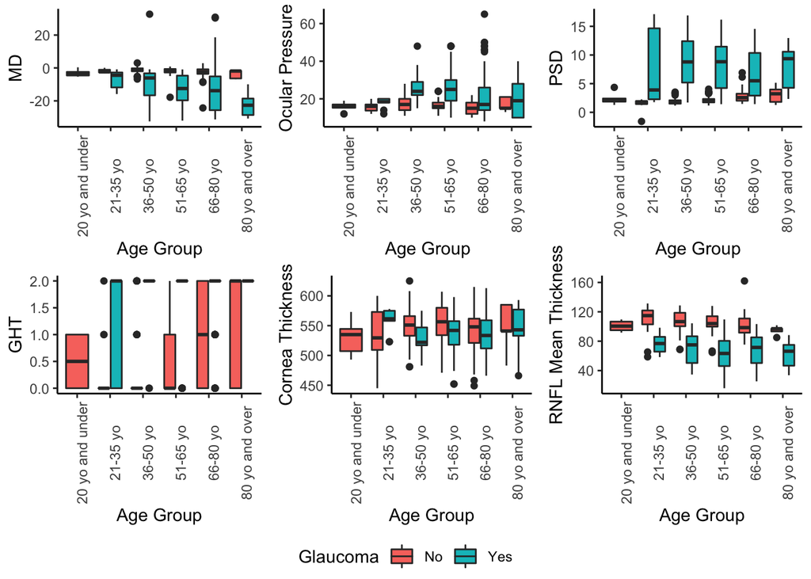

# Glaucoma diagnosis predicted by RNFL mean thickness

In the machine learning decision tree, the first factor examined for used for determining an individual’s glaucoma status is the RNFL mean thickness. The authors used a RNFL mean thickness of 89.33334 as their initial criteria in their glaucoma decision tree. Here, I examine how many individuals would be correctly diagnosed by RNFL mean thickness alone and ask: Is the chosen RNFL mean thickness value the best value for distinguishing between the glaucoma-positive and glaucoma-negative individuals or does a better value exist?

## Calculating the number of individuals correctly and incorrectly diagnosis on RNFL mean thickness value alone.

This section filters the dataset to determine how many individuals can be correctly diagnosed with RNFL mean thickness alone and calculates the false positive and false negative rates.

```r
#Counting number of individuals correctly predicted to not have glaucoma and calculating the false negative rate

dataset %>%
  filter(RNFL4.mean > 89.33334) %>%
  group_by(glaucoma) %>%
  count() %>%
  ungroup() %>%
  mutate(Percent=n/sum(n)*100) -> RNFL_no_glaucoma_89

#Counting number of individuals correctly predicted to  have glaucoma and calculating the false positive rate

dataset %>%
  filter(RNFL4.mean <= 89.33334) %>%
  group_by(glaucoma) %>%
  count() %>%
  ungroup() %>%
  mutate(Percent=n/sum(n)*100) -> RNFL_glaucoma_89

#Printing the results

print(paste0(RNFL_glaucoma_89[2,2], ' individuals were correctly predicted to have glaucoma and ',  RNFL_no_glaucoma_89[1,2], ' individual were correctly to predicted to not have glaucoma using a RNFL4 mean thickness of 89.3334. The false positive rate was ', RNFL_glaucoma_89[1,3], ' and the false negative rate was ', RNFL_no_glaucoma_89[2,3], '.'))
```

```
## [1] "254 individuals were correctly predicted to have glaucoma and 186 individual were correctly to predicted to not have glaucoma using a RNFL4 mean thickness of 89.3334. The false positive rate was 5.92592592592593 and the false negative rate was 18.7772925764192."
```

```r
#Repeating analysis with RNFL mean thickness of 87

dataset %>%
  filter(RNFL4.mean > 87) %>%
  group_by(glaucoma) %>%
  count() %>%
  ungroup() %>%
  mutate(Percent=n/sum(n)*100) -> RNFL_no_glaucoma_87

dataset %>%
  filter(RNFL4.mean <= 87) %>%
  group_by(glaucoma) %>%
  count() %>%
  ungroup() %>%
  mutate(Percent=n/sum(n)*100) -> RNFL_glaucoma_87

print(paste0(RNFL_glaucoma_87[2,2], ' individuals were correctly predicted to have glaucoma and ',  RNFL_no_glaucoma_87[1,2], ' individual were correctly to predicted to not have glaucoma using a RNFL4 mean thickness of 87. The false positive rate was ', RNFL_glaucoma_87[1,3], ' and the false negative rate was ', RNFL_no_glaucoma_87[2,3], '.'))
```

```
## [1] "241 individuals were correctly predicted to have glaucoma and 188 individual were correctly to predicted to not have glaucoma using a RNFL4 mean thickness of 87. The false positive rate was 5.49019607843137 and the false negative rate was 22.9508196721311."
```

```r
#Repeating analysis with RNFL mean thickness of 91

dataset %>%
  filter(RNFL4.mean > 91) %>%
  group_by(glaucoma) %>%
  count() %>%
  ungroup() %>%
  mutate(Percent=n/sum(n)*100) -> RNFL_no_glaucoma_91

dataset %>%
  filter(RNFL4.mean <= 91) %>%
  group_by(glaucoma) %>%
  count() %>%
  ungroup() %>%
  mutate(Percent=n/sum(n)*100) -> RNFL_glaucoma_91

print(paste0(RNFL_glaucoma_91[2,2], ' individuals were correctly predicted to have glaucoma and ',  RNFL_no_glaucoma_91[1,2], ' individual were correctly to predicted to not have glaucoma using a RNFL4 mean thickness of 91. The false positive rate was ', RNFL_glaucoma_91[1,3], ' and the false negative rate was ', RNFL_no_glaucoma_91[2,3], '.'))
```

```
## [1] "261 individuals were correctly predicted to have glaucoma and 180 individual were correctly to predicted to not have glaucoma using a RNFL4 mean thickness of 91. The false positive rate was 7.77385159010601 and the false negative rate was 16.6666666666667."
```

## Plotting the distribution of RNFL mean thickness for glaucoma-positive and glaucoma-negative individuals

This section plots the RNFL mean thickness stratified by glaucoma status to examine why choosing a RNFL mean thickness greater or less than 89.33334 increased the false positive or false negative rates, respectively.

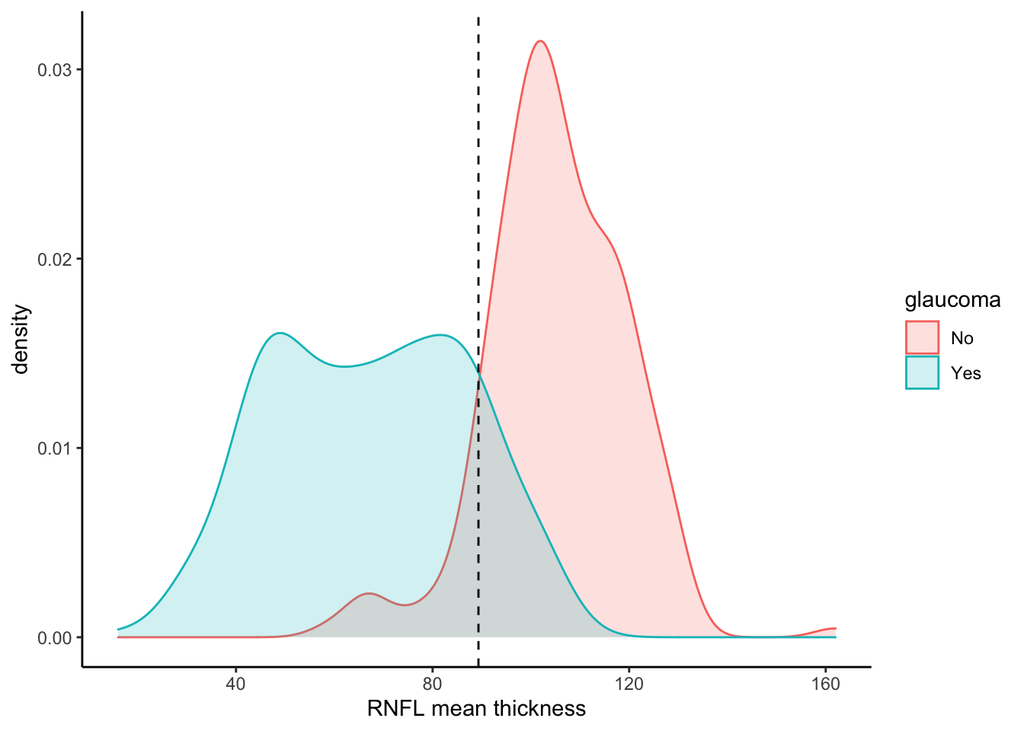

```r
#Creating density plot

RNFL_density_plot <- ggplot(dataset, aes(x = RNFL4.mean, color = glaucoma, fill = glaucoma)) + geom_density(alpha = 0.2) + theme_classic() + geom_vline(xintercept = 89.33334, linetype = 'dashed') + xlab('RNFL mean thickness')

#Displaying plot

plot(RNFL_density_plot)
```

```r
#Saving the plot

ggsave('results/RNFL_mean_thickness_density_plot.png')
```

I chose to represent the distribution RNFL mean thickness as a density plot as it allowed for an easy visual examination of the distributions of the glaucoma-positive and glaucoma-negative groups. I kept the color identical to the previous plots for easy visual interpretation.

The analysis here shows that increasing the RNFL mean thickness for would increase the false positive rate while decreasing the RNFL mean thickness would increase the false negative rate. This is further demonstrated in the density plot which shows shifting the chosen RNFL mean thickness value impacts the number of false positive or false negative cases since the distribution overlap. Together, this demonstrates that RNFL mean thickness alone is not a perfect predictor of glaucoma status.

# Reproducibility

The analysis presented in the original manuscript was mostly reproducible, but some modifications would have improved the reproducibility. No data on the full list of factors that included gender and VFI were available and such I could not confirm that the presented factors were indeed the best factors for building a machine learning model for glaucoma diagnosis. Second, additional documentation on their analysis approach would have improved my ability to reproduce the data. For example, the PCA presented in Figure 2 was scaled, but this was not mentioned in the text. Finally, no code was available for reproducing their figures and conclusions. The availability of such code would greatly improve the reproducibility.

My analysis is highly reproducible. All code is documented and commented in this R markdown file or the following Jupyter Notebook. The data used are also available in the following data directory.